# DoubletFinder_SingleR

Selda Akdal

2024-09-23

# Tek Hücre RNA-Seq Analizi Eğitimi-Seurat (scRNA-Seq)

## Seurat, DoubletFinder ve SingleR ile scRNAseq Analizi

### Standart Ön-İşlem

DoubletFinder işlemi yapılmadan önce verilerin standart ön işlemi gerçekleştirilmelidir. Temel paketler yüklenir.

```r
#install.packages("devtools")
#devtools::install_github('chris-mcginnis-ucsf/DoubletFinder')  # DoubletF,nder paketi github'dan alındı.

#install.packages("Seurat")
#install.pacakges("tidyverse)

library(DoubletFinder)
library(Seurat)
library(tidyverse)
```

Veriler mtx formatında olduğu için verilerin yüklenmesinde ReadMtx() kullanılır.

```r
cts <- ReadMtx(mtx = "GSE202501_RAW/GSM6123277_matrix.mtx.gz",
               features = "GSE202501_RAW/GSM6123277_features.tsv.gz",
               cells = "GSE202501_RAW/GSM6123277_barcodes.tsv.gz")
```

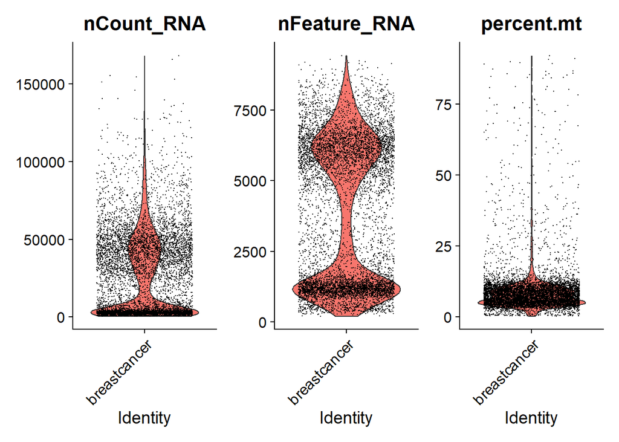

```r
breastcancer <- CreateSeuratObject(counts = cts, project = "breastcancer", min.cells = 3, min.features = 200)

View(breastcancer@meta.data)

breastcancer$percent.mt <- PercentageFeatureSet(breastcancer, pattern = "^MT-")

VlnPlot(breastcancer, features = c("nCount_RNA", "nFeature_RNA", "percent.mt"))
```

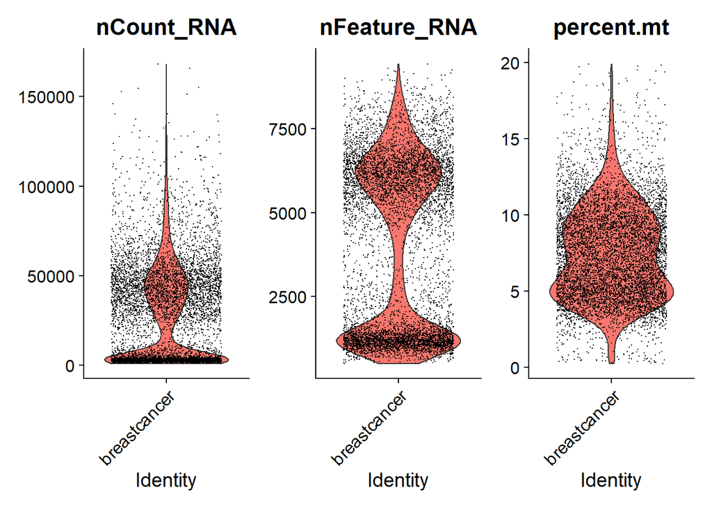

```r
breastcancer <- subset(breastcancer, subset = nCount_RNA > 1000 & nFeature_RNA > 500 & percent.mt < 20)

VlnPlot(breastcancer, features = c("nCount_RNA", "nFeature_RNA", "percent.mt"))
```

```r
breastcancer <- NormalizeData(breastcancer)
```

```
## Normalizing layer: counts
```

```r
breastcancer <- FindVariableFeatures(breastcancer)
```

```
## Finding variable features for layer counts
```

```r
breastcancer <- ScaleData(breastcancer)
breastcancer <- RunPCA(breastcancer)
```

```
## PC_ 1
## Positive:  VIM, S100A4, PTPRC, CYBA, CORO1A, CD52, EMP3, IL32, FYB1, TRAC
##     CD2, LAPTM5, SRGN, LGALS1, LDHB, TRBC2, LTB, LCP1, IL7R, CXCR4
##     XIST, CD74, ITGB2, CCL5, GZMA, LSP1, CST7, HLA-DPB1, COTL1, HLA-DPA1
## Negative:  KRT8, KRT18, AGR2, AZGP1, LGALS3, SERHL2, CLDN4, SRD5A3, NUPR1, ALCAM
##     MGST1, PDLIM3, AQP3, CLU, VTCN1, SDC1, TNFRSF12A, NAMPT, SLC12A2, MACC1
##     LRRC26, DSP, SLPI, USP53, TRPV6, PIP, HSPB1, PDZK1IP1, CYP51A1, CLGN
## PC_ 2
## Positive:  MKI67, CENPF, CDKN3, PBK, NUSAP1, GTSE1, HMMR, KNL1, TOP2A, UBE2C
##     PCLAF, TPX2, CDK1, BIRC5, KIF4A, CENPW, CCNB2, ZWINT, PRC1, RRM2
##     STMN1, KIFC1, ASPM, SGO1, KIF23, DLGAP5, CEP55, CCNB1, HJURP, OIP5
## Negative:  AREG, GPRC5A, FSTL3, TMEM265, DEPP1, SDCBP2, KLF4, TRIM16, ATF3, CEACAM5
##     ITGB8, ANXA3, NEDD9, TCIM, GOLM1, EDN1, KLF6, NTN4, SOX4, MGLL
##     PDGFB, TRIM47, CLDN4, PPP1R15A, SPNS2, RAET1L, DSC2, TGFB2, HSPB1, LURAP1L
## PC_ 3
## Positive:  IL32, TRAC, CD52, CD2, TRBC2, IL7R, LTB, GZMA, CCL5, GZMK
##     TRBC1, IFITM1, CST7, TUBA4A, LDHB, NKG7, CD27, KLRB1, CTSW, CD7
##     CD69, GZMH, PRF1, ISG20, CRIP1, CXCR4, MAL, KLRG1, HOPX, KLRK1
## Negative:  CST3, LYZ, MS4A6A, AIF1, CYBB, FCER1G, FCGR2A, CPVL, MARCH1, SPI1
##     CD14, FGL2, KCTD12, IFI30, CSF1R, MEF2C, PLXDC2, CLEC7A, TYROBP, MPEG1
##     CD86, VSIG4, LY86, MNDA, FCGR1A, FPR1, FCGRT, TGFBI, CD68, IGSF6
## PC_ 4
## Positive:  GPRC5A, RAET1L, TGFB2, TM4SF1, MGLL, ITGB8, SDCBP2, AREG, TRIM16, SFN
##     SPATS2L, LMO7, TRIM16L, PLAU, CEACAM5, EMP1, CDKN2B, MYO5B, TMEM265, ANXA3
##     ANXA1, KLF4, LINC01133, DEPP1, FSTL3, LTBP1, TRIM47, MALL, C1orf116, BBC3
## Negative:  TFAP2B, PIP, SPINK8, GLYATL1, SRARP, MUCL1, SLC40A1, CREB3L4, SELENOP, AP001636.3
##     AC008771.1, LRRC26, SLC5A8, APOD, MPHOSPH6, VAV3, CYP4Z1, CYB5A, CLGN, HSD17B2
##     CA12, KMO, KYNU, ABCC11, CLCA2, FBP1, GLYATL2, CSTA, KIAA1324, PRLR
## PC_ 5
## Positive:  CEACAM6, MUC16, MUC21, VSIG2, TSPAN1, CALML5, CRABP2, CEACAM5, CCNB1, TSPAN8
##     C15orf48, PSCA, CDC20, SLC9A2, ADGRF1, FFAR2, INSIG1, PLK1, SECTM1, PRR15
##     QSOX1, FGFBP1, AURKA, HMMR, TROAP, GDF15, KNSTRN, TSPAN3, DEPDC1, BUB1
## Negative:  FAM111B, RRM2, E2F1, MYBL2, ACTN1, CDC45, THBS1, PALLD, RASSF6, CCN2
##     MCM10, CPEB2, RIBC2, TMEM217, CLSPN, C1QTNF2, CDC6, USP53, FHL2, DAPK3
##     PDGFB, DTL, TCIM, VCL, CNIH2, GINS2, CAMSAP2, PKMYT1, TRIB1, ANKRD30A
```

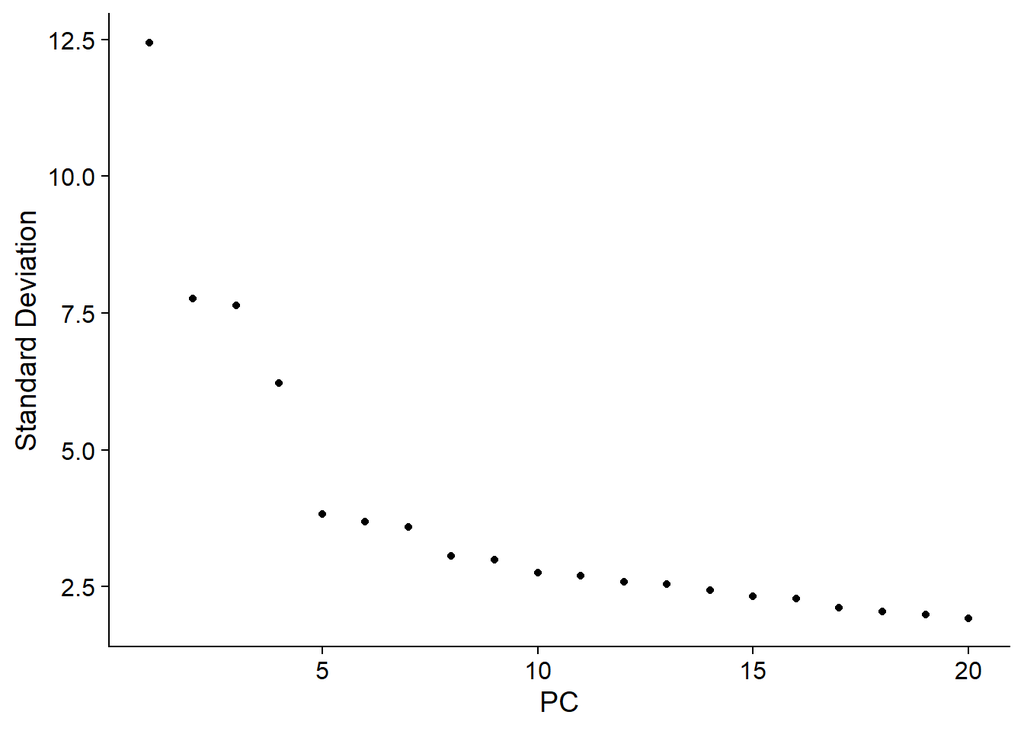

```r
ElbowPlot(breastcancer)
```

```r
breastcancer <- FindNeighbors(breastcancer, dims = 1:15)
breastcancer <- FindClusters(breastcancer, resolution = 0.7)
```

```
## Modularity Optimizer version 1.3.0 by Ludo Waltman and Nees Jan van Eck
##
## Number of nodes: 7510
## Number of edges: 251010
##
## Running Louvain algorithm...
## Maximum modularity in 10 random starts: 0.8549
## Number of communities: 14
## Elapsed time: 2 seconds
```

```r
breastcancer <- RunUMAP(breastcancer, dims = 1:15)
```

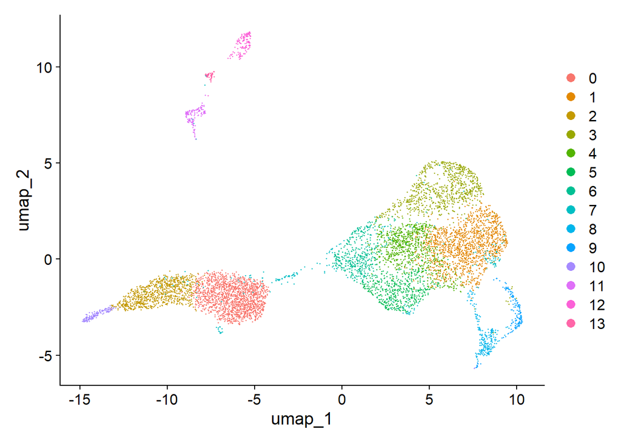

```r
DimPlot(breastcancer, reduction = "umap")
```

### Doublet Tahmini

Standart ön-işlem analizleri gerçekleştirildikten sonra doubletFinder ile doublet tahmini yapılır. DoubletFinder, tek hücreli RNA dizileme (scRNA-seq) verilerinde çift hücrelerin (doublets) tespit edilmesini sağlayan bir yöntemdir. Çift hücreler, genellikle aynı hücre içinde iki veya daha fazla hücrenin karışımını temsil eder ve bu durum analizin doğruluğunu etkileyebilir. DoubletFinder, bu tür çift hücrelerin tespit edilmesine ve ayıklanmasına yardımcı olur.

```r
# pK Tanımlaması (no ground-truth)

sweep.res.list_cancer <- paramSweep(breastcancer, PCs = 1:15, sct = FALSE)
```

[output not shown]

[output not shown]

[output not shown]

```
## Normalizing layer: counts
```

```
## [1] "Finding variable genes..."
```

```
## Finding variable features for layer counts
```

```
## [1] "Scaling data..."
```

[output not shown]

[output cut: 23 more lines]

[output not shown]

```
## [1] "Finding variable genes..."
```

```
## Finding variable features for layer counts
```

```
## [1] "Scaling data..."
```

[output not shown]

[output cut: 23 more lines]

[output not shown]

```
## [1] "Finding variable genes..."
```

```
## Finding variable features for layer counts
```

```
## [1] "Scaling data..."
```

[output not shown]

[output cut: 23 more lines]

[output not shown]

```
## [1] "Finding variable genes..."
```

```
## Finding variable features for layer counts
```

```
## [1] "Scaling data..."
```

[output not shown]

[output cut: 23 more lines]

[output not shown]

```
## [1] "Finding variable genes..."
```

```
## Finding variable features for layer counts
```

```
## [1] "Scaling data..."
```

[output not shown]

[output cut: 23 more lines]

[output not shown]

```
## [1] "Finding variable genes..."
```

```
## Finding variable features for layer counts
```

```
## [1] "Scaling data..."
```

[output not shown]

[output cut: 20 more lines]

```r
sweep.stats_cancer <- summarizeSweep(sweep.res.list_cancer, GT = FALSE)
```

[output not shown]

```r
bcmvn_cancer <- find.pK(sweep.stats_cancer)
```

[figure not shown]

paramSweep:Verinin çeşitli pK değerleri için nasıl performans gösterdiğini test eder. Bu, farklı pK parametreleri ile doubletlerin tespit edilmesini sağlar.

summarizeSweep: paramSweep adımında elde edilen sonuçları özetler ve performans metriklerini toplar.

find.pK: Özetlenmiş sonuçlardan en uygun pK değerini belirler. Bu pK değeri, en iyi doublet tespiti performansını sağlayacak şekilde seçilir.

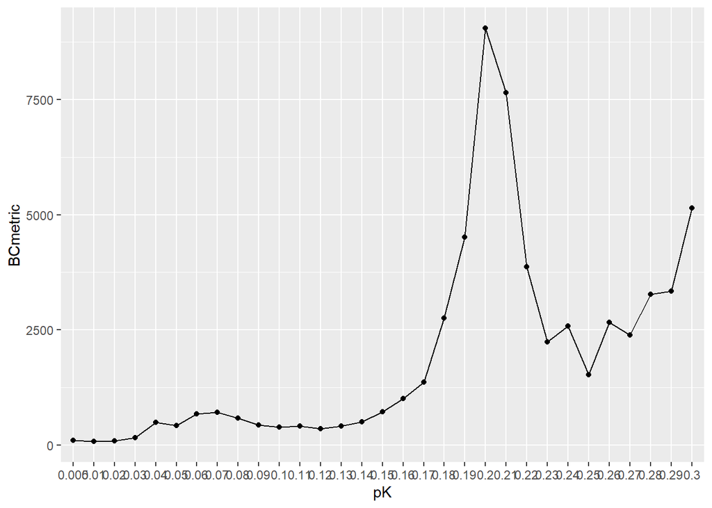

```r
#pK değerlerini görüntülemek için görselleştirme
ggplot(bcmvn_cancer, aes(pK, BCmetric, group = 1)) +
  geom_point() +
  geom_line()
```

```r
pK <- bcmvn_cancer %>% # doublet algılamayı optimize etmek için maksimum bcmvn'ye karşılık gelen pK'yi seçin
  filter(BCmetric == max(BCmetric)) %>% # BCmetric'in maksimum değerine karşılık gelen satırı filtreleyin
  select(pK) # Filtrelenmiş satırlardan pK değerini seçin
```

as.character ile karaktere dönüştürülmüş değeri as.numeric ile tekrar sayısal veri tipine dönüştürür. Bu adım, verinin sayısal hesaplamalar için uygun bir formata getirilmesini sağlar.pK bir veri çerçevesi veya liste olabilir ve bu kod parçası, pK içindeki ilk elemanı alır.

```r
pK <- as.numeric(as.character(pK[[1]]))
```

```r
## Homotypic Doublet Oranı Tahmini ######

#seurat_clusters genellikle hücrelerin kümeleme sonuçlarını içerir ve bu bilgiler doublet tespiti için kullanılır.
annotations <- breastcancer@meta.data$seurat_clusters

homotypic.prop <- modelHomotypic(annotations) #annotations verileri kullanarak homotipik (aynı hücre tipinden) doublet oranını tahmin eder.

nExp_poi <- round(0.076*nrow(breastcancer@meta.data)) #Doubletlerin tahmin edilen sayısını hesaplar.

nExp_poi.adj <- round(nExp_poi*(1-homotypic.prop)) #Homotipik doublet oranını dikkate alarak düzeltilmiş doublet tahmini yapar.
```

```r
#doubletFinder ile doublet tespiti yapılır. Analizler sonucu elde edilen değerler burada input olarak girilir.
breastcancer <- doubletFinder(breastcancer,
                              PCs = 1:15,
                              pK=pK,
                              pN=0.25,
                              nExp = nExp_poi.adj)
```

```
## [1] "Creating 2503 artificial doublets..."
## [1] "Creating Seurat object..."
## [1] "Normalizing Seurat object..."
```

```
## Normalizing layer: counts
```

```
## [1] "Finding variable genes..."
```

```
## Finding variable features for layer counts
```

```
## [1] "Scaling data..."
```

```
## [1] "Running PCA..."
## [1] "Calculating PC distance matrix..."
## [1] "Computing pANN..."
## [1] "Classifying doublets.."
```

```r
View(breastcancer@meta.data)
head(breastcancer@meta.data)
```

```
##                      orig.ident nCount_RNA nFeature_RNA percent.mt
## AAACCCAAGTGCAGGT-1 breastcancer       3444         1230   4.442509
## AAACCCACACATAACC-1 breastcancer      36961         5660   5.927870
## AAACCCAGTGGACCTC-1 breastcancer       1956          941   5.725971
## AAACCCATCACCTCGT-1 breastcancer      34934         5668   8.747925
## AAACGAAAGGTTGAGC-1 breastcancer       2204         1107   5.127042
## AAACGAACACAGCGCT-1 breastcancer       3719         1394   4.114009
##                    RNA_snn_res.0.7 seurat_clusters pANN_0.25_0.2_499
## AAACCCAAGTGCAGGT-1               0               0        0.08587119
## AAACCCACACATAACC-1               3               3        0.31352971
## AAACCCAGTGGACCTC-1               2               2        0.08237644
## AAACCCATCACCTCGT-1               3               3        0.32601098
## AAACGAAAGGTTGAGC-1               2               2        0.12031952
## AAACGAACACAGCGCT-1               0               0        0.08587119
##                    DF.classifications_0.25_0.2_499
## AAACCCAAGTGCAGGT-1                         Singlet
## AAACCCACACATAACC-1                         Singlet
## AAACCCAGTGGACCTC-1                         Singlet
## AAACCCATCACCTCGT-1                         Singlet
## AAACGAAAGGTTGAGC-1                         Singlet
## AAACGAACACAGCGCT-1                         Singlet
```

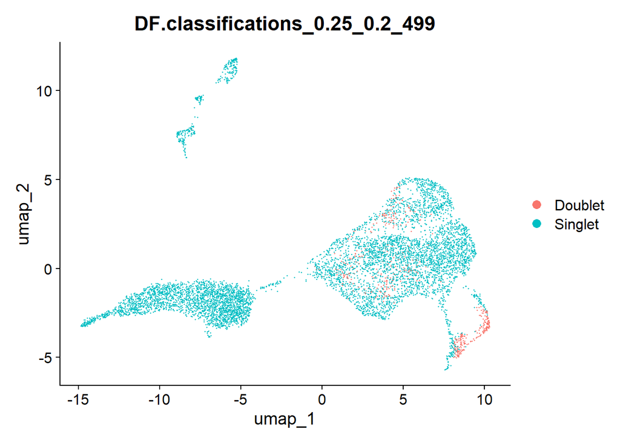

```r
DimPlot(breastcancer, reduction = "umap", group.by = "DF.classifications_0.25_0.2_499")
```

DoubletFinder ile doublet tespiti yapıldıktan sonra doubletlerin filtrelenmesi gerekir. Bu işlem için subset() fonksiyonu kullanılabilir.

```r
breastcancerfiltered <- subset(breastcancer, subset = DF.classifications_0.25_0.2_499 == "Singlet")
```

Filtreleme işlemi yapıldıktan sonra tekrar standart ön-işlem analizleri yapılmalıdır.

```r
breastcancerfiltered <- breastcancerfiltered %>%
  NormalizeData() %>%
  FindVariableFeatures() %>%
  ScaleData() %>%
  RunPCA() %>%
  FindNeighbors(dims = 1:15) %>%
  FindClusters() %>%
  RunUMAP(dims = 1:15)
```

```
## Normalizing layer: counts
```

```
## Finding variable features for layer counts
```

```
## PC_ 1
## Positive:  VIM, S100A4, CYBA, CORO1A, CD52, EMP3, IL32, TRAC, CD2, LAPTM5
##     SRGN, LDHB, LGALS1, TRBC2, LTB, LCP1, IL7R, CXCR4, XIST, CD74
##     CCL5, ITGB2, GZMA, LSP1, CST7, HLA-DPB1, COTL1, HLA-DRB1, HLA-DPA1, ALOX5AP
## Negative:  TACSTD2, KRT8, LMNA, CLDN3, ENAH, KRT18, AGR2, AZGP1, CLDN4, EPHX1
##     LGALS3, SERHL2, SRD5A3, PDLIM3, NUPR1, ALCAM, AQP3, NR2F2, VTCN1, MGST1
##     LIMCH1, TNFRSF12A, SDC1, NAMPT, SLC12A2, MACC1, CLU, USP53, DSP, TRPV6
## PC_ 2
## Positive:  IL32, TRAC, CD52, CD2, TRBC2, IL7R, LTB, GZMA, CCL5, GZMK
##     TRBC1, IFITM1, CST7, LDHB, CRIP1, NKG7, CD27, KLRB1, CTSW, CD7
##     CD69, GZMH, PRF1, ISG20, CXCR4, MAL, HOPX, KLRG1, KLRK1, TRGC2
## Negative:  CST3, LYZ, MS4A6A, AIF1, CYBB, FCER1G, FCGR2A, CPVL, MARCH1, SPI1
##     CD14, FGL2, KCTD12, IFI30, CSF1R, MEF2C, CLEC7A, PLXDC2, TYROBP, MPEG1
##     CD86, VSIG4, LY86, MNDA, FPR1, FCGR1A, FCGRT, TGFBI, CD68, IGSF6
## PC_ 3
## Positive:  GPRC5A, RAET1L, TGFB2, ITGB8, AREG, TM4SF1, MGLL, SDCBP2, TRIM16, TMEM265
##     LMO7, FSTL3, CEACAM5, PLAU, DEPP1, SPATS2L, ANXA3, TRIM16L, MYO5B, KLF4
##     TRIM47, EMP1, CDKN2B, PDGFB, CCL22, ATF3, BBC3, ANXA1, SFN, KRT80
## Negative:  TFAP2B, PIP, SPINK8, SRARP, MUCL1, CREB3L4, GLYATL1, AC008771.1, SLC40A1, LRRC26
##     SELENOP, MPHOSPH6, CLGN, APOD, VAV3, FBP1, AP001636.3, PRLR, ABCC11, SELENBP1
##     KYNU, CYP4Z1, CSTA, SLC5A8, COMT, CYB5A, CLCA2, PON2, REEP6, CA12
## PC_ 4
## Positive:  GLYATL2, GLYATL1, CCN2, SLC5A8, TCIM, SLC40A1, KMO, HSD17B2, AP001636.3, C2CD4B
##     AC010329.1, ONECUT2, CYP4X1, CDC42EP5, FHL2, PALLD, NR4A1, SEMA3B, FOS, TTC36
##     KIAA1324, TFAP2B, HIST1H2AC, CGREF1, S100A8, PDLIM3, PMP22, TMEM86A, USP53, VCL
## Negative:  BIRC5, HMMR, CENPF, CCNB1, MKI67, CCNB2, CDKN3, CDC20, GTSE1, DLGAP5
##     TPX2, CENPW, STMN1, ASPM, TROAP, PTTG1, KIF4A, DEPDC1, UBE2C, CEP55
##     PBK, KNL1, PRC1, NUSAP1, PCLAF, BUB1, AURKA, NEK2, PLK1, KIF23
## PC_ 5
## Positive:  CEACAM6, MUC16, TSPAN1, MUC21, PSCA, VSIG2, ADGRF1, CALML5, CEACAM5, TSPAN8
##     CRABP2, SECTM1, FGFBP1, C15orf48, PRR15, GDF15, LINC01133, LRATD1, PTGES, SLC9A2
##     TSPAN3, FFAR2, PI3, QSOX1, SCEL, KDR, MESP1, INSIG1, EPB41L4B, PLEKHS1
## Negative:  CCN2, VCL, RASSF6, PALLD, ACTN1, DAPK3, THBS1, FHL2, ANLN, PDGFB
##     CPEB2, TMEM217, ANKRD30A, SLC20A2, CAMSAP2, USP53, MYADM, WEE1, ZYX, CLIP1
##     ACTG1, TCIM, TRIB1, KIAA0895, CSRP1, PTGER4, FERMT2, MYH9, ONECUT2, TMEM237
```

```
## Modularity Optimizer version 1.3.0 by Ludo Waltman and Nees Jan van Eck
##
## Number of nodes: 7011
## Number of edges: 235985
##
## Running Louvain algorithm...
## Maximum modularity in 10 random starts: 0.8372
## Number of communities: 14
## Elapsed time: 1 seconds
```

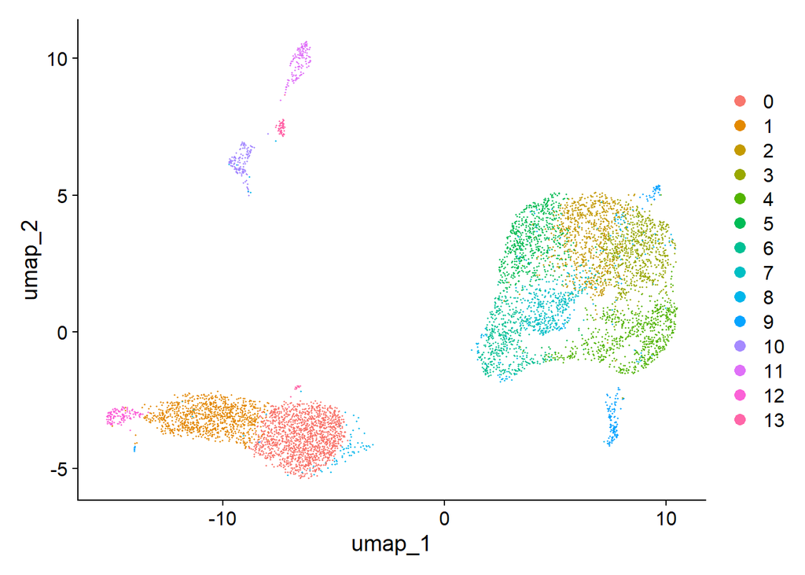

```r
DimPlot(breastcancerfiltered, reduction = "umap")
```

### SingleR ile Hücre Ataması

DoubletFinder ile doublet tespiti yapıp, filtreleme işlemini gerçekleştirdikten sonra standart ön-işlem analizleri tekrarlanır. Bu işlemler tamamlandıktan sonra hücrelerin ataması SingleR paketi ile yapılabilir.

```r
#if (!require("BiocManager", quietly = TRUE))
  #install.packages("BiocManager")

#BiocManager::install("SingleR")   #SingleR paketi github kodu ile kurulur.

#if (!require("BiocManager", quietly = TRUE))
  #install.packages("BiocManager")

#BiocManager::install("celldex")   #celldex paketi github kodu ile kurulur.

library(SingleR)                #SingleR paketi aktif edilir.
library(celldex)                #celldex paketi aktif edilir.
```

celldex paketi, hücre tiplerini ve referans veri setlerini içeren çeşitli veri kaynaklarını sağlar. Bu veri setleri, tek hücreli RNA dizileme (scRNA-seq) analizlerinde referans olarak kullanılır.

HumanPrimaryCellAtlasData, celldex paketinin bir fonksiyonudur ve insanın çeşitli primer hücre tiplerinin gen ekspresyon profillerini içeren bir veri setini döndürür.

```r
ref <- celldex::HumanPrimaryCellAtlasData()
```

```
## see ?celldex and browseVignettes('celldex') for documentation
```

```
## loading from cache
```

```
## see ?celldex and browseVignettes('celldex') for documentation
```

```
## loading from cache
```

```r
View(as.data.frame(colData(ref)))
```

```r
#Bu fonksiyon, gen ekspresyon matrisini veya diğer verileri çıkarmak için kullanılır.
breast_counts <- GetAssayData(object = breastcancerfiltered, layer = "data")
```

```r
#SingleR fonksiyonunu kullanarak breast_counts verisini referans veri seti ref ile karşılaştırarak hücre tiplerini tahmin eder.
pred <- SingleR(test = breast_counts,
        ref = ref,
        labels = ref$label.main)
```

```r
#Tahmin edilen hücre tiplerini seurat objesine entegre etme
breastcancerfiltered$singleR <- pred$labels

head(breastcancerfiltered@meta.data)
```

```
##                      orig.ident nCount_RNA nFeature_RNA percent.mt
## AAACCCAAGTGCAGGT-1 breastcancer       3444         1230   4.442509
## AAACCCACACATAACC-1 breastcancer      36961         5660   5.927870
## AAACCCAGTGGACCTC-1 breastcancer       1956          941   5.725971
## AAACCCATCACCTCGT-1 breastcancer      34934         5668   8.747925
## AAACGAAAGGTTGAGC-1 breastcancer       2204         1107   5.127042
## AAACGAACACAGCGCT-1 breastcancer       3719         1394   4.114009
##                    RNA_snn_res.0.7 seurat_clusters pANN_0.25_0.2_499
## AAACCCAAGTGCAGGT-1               0               0        0.08587119
## AAACCCACACATAACC-1               3               4        0.31352971
## AAACCCAGTGGACCTC-1               2               1        0.08237644
## AAACCCATCACCTCGT-1               3               4        0.32601098
## AAACGAAAGGTTGAGC-1               2               1        0.12031952
## AAACGAACACAGCGCT-1               0               0        0.08587119
##                    DF.classifications_0.25_0.2_499 RNA_snn_res.0.8
## AAACCCAAGTGCAGGT-1                         Singlet               0
## AAACCCACACATAACC-1                         Singlet               4
## AAACCCAGTGGACCTC-1                         Singlet               1
## AAACCCATCACCTCGT-1                         Singlet               4
## AAACGAAAGGTTGAGC-1                         Singlet               1
## AAACGAACACAGCGCT-1                         Singlet               0
##                             singleR
## AAACCCAAGTGCAGGT-1          T_cells
## AAACCCACACATAACC-1 Epithelial_cells
## AAACCCAGTGGACCTC-1          T_cells
## AAACCCATCACCTCGT-1 Epithelial_cells
## AAACGAAAGGTTGAGC-1          T_cells
## AAACGAACACAGCGCT-1          T_cells
```

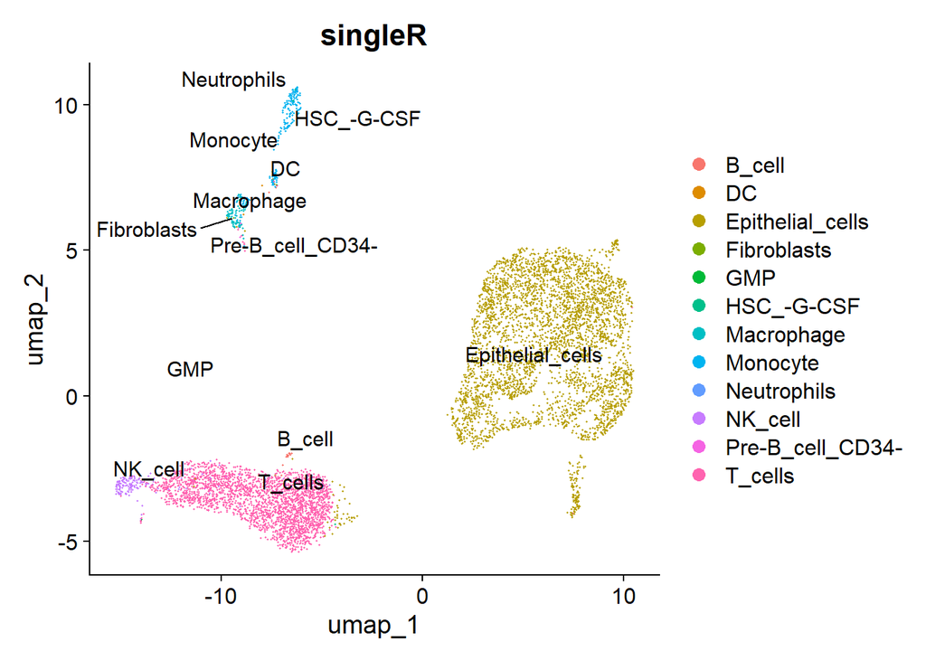

```r
DimPlot(breastcancerfiltered, reduction = "umap", group.by = "singleR", label = T, repel = T)
```

Bu işlemin devamında FindAllMarkers() fonksiyonu kullanılarak hücreler özelinde genlerin tanımlanması gerçekleştirilebilir.

```r
Idents(breastcancerfiltered) <- breastcancerfiltered$singleR

pbmc.markers <- FindAllMarkers(breastcancerfiltered, only.pos = TRUE)
```

[output not shown]

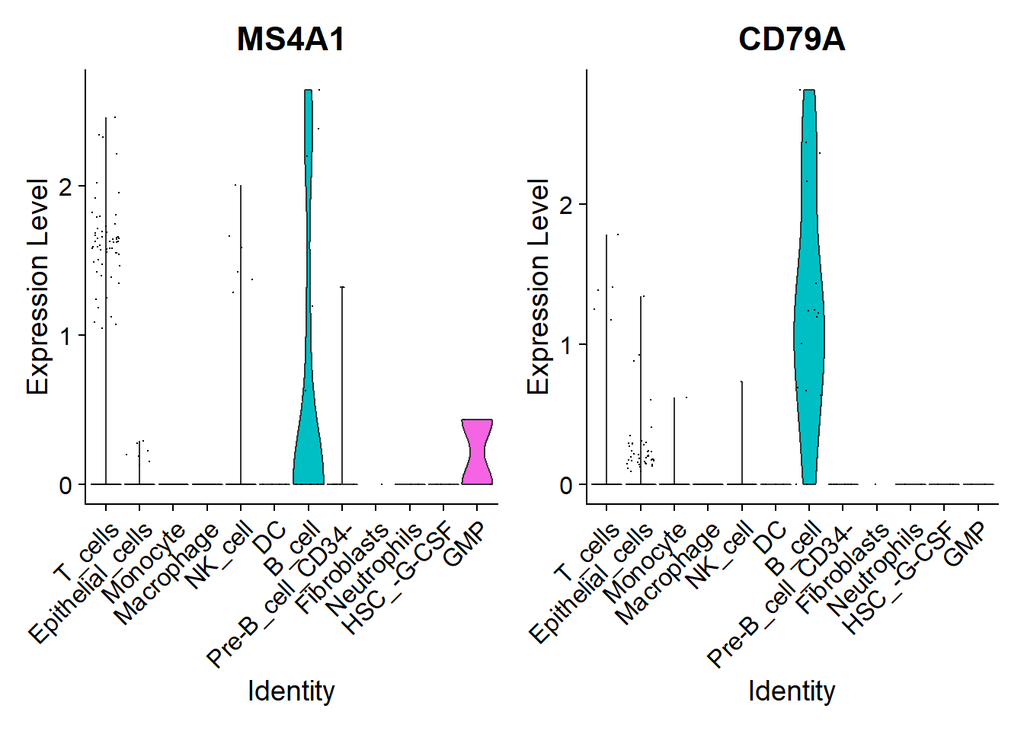

```r
VlnPlot(breastcancerfiltered, features = c("MS4A1", "CD79A"))
```

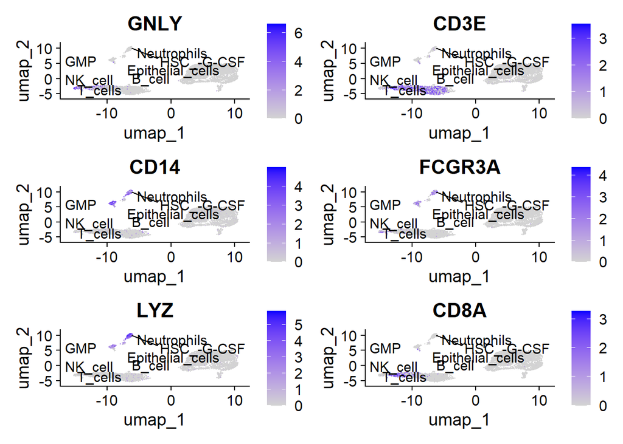

```r
FeaturePlot(breastcancerfiltered, features = c("GNLY", "CD3E", "CD14", "FCGR3A", "LYZ","CD8A"), label=T, repel = T)
```